# Chapter 4: Clustering and classification

## Standardization and train/test division

For the following analysis, I standardize the variables in the dataset. The function ‘scale’ does this action From the summary of the standardized data, observe that all variables have now mean zero.

```
##       crim                 zn               indus
##  Min.   :-0.419367   Min.   :-0.48724   Min.   :-1.5563
##  1st Qu.:-0.410563   1st Qu.:-0.48724   1st Qu.:-0.8668
##  Median :-0.390280   Median :-0.48724   Median :-0.2109
##  Mean   : 0.000000   Mean   : 0.00000   Mean   : 0.0000
##  3rd Qu.: 0.007389   3rd Qu.: 0.04872   3rd Qu.: 1.0150
##  Max.   : 9.924110   Max.   : 3.80047   Max.   : 2.4202
##       chas              nox                rm               age
##  Min.   :-0.2723   Min.   :-1.4644   Min.   :-3.8764   Min.   :-2.3331
##  1st Qu.:-0.2723   1st Qu.:-0.9121   1st Qu.:-0.5681   1st Qu.:-0.8366
##  Median :-0.2723   Median :-0.1441   Median :-0.1084   Median : 0.3171
##  Mean   : 0.0000   Mean   : 0.0000   Mean   : 0.0000   Mean   : 0.0000
##  3rd Qu.:-0.2723   3rd Qu.: 0.5981   3rd Qu.: 0.4823   3rd Qu.: 0.9059
##  Max.   : 3.6648   Max.   : 2.7296   Max.   : 3.5515   Max.   : 1.1164
##       dis               rad               tax             ptratio
##  Min.   :-1.2658   Min.   :-0.9819   Min.   :-1.3127   Min.   :-2.7047
##  1st Qu.:-0.8049   1st Qu.:-0.6373   1st Qu.:-0.7668   1st Qu.:-0.4876
##  Median :-0.2790   Median :-0.5225   Median :-0.4642   Median : 0.2746
##  Mean   : 0.0000   Mean   : 0.0000   Mean   : 0.0000   Mean   : 0.0000
##  3rd Qu.: 0.6617   3rd Qu.: 1.6596   3rd Qu.: 1.5294   3rd Qu.: 0.8058
##  Max.   : 3.9566   Max.   : 1.6596   Max.   : 1.7964   Max.   : 1.6372
##      black             lstat              medv
##  Min.   :-3.9033   Min.   :-1.5296   Min.   :-1.9063
##  1st Qu.: 0.2049   1st Qu.:-0.7986   1st Qu.:-0.5989
##  Median : 0.3808   Median :-0.1811   Median :-0.1449
##  Mean   : 0.0000   Mean   : 0.0000   Mean   : 0.0000
##  3rd Qu.: 0.4332   3rd Qu.: 0.6024   3rd Qu.: 0.2683
##  Max.   : 0.4406   Max.   : 3.5453   Max.   : 2.9865
```

Then, I transform the continuous variable ‘crim’ into a categorical variable by using its quatiles, and I add a new categorical variable ‘crime’ to the ‘boston_scaled’ dataset.

```r
summary(boston_scaled$crime)
```

```
##      low  med_low med_high     high
##      127      126      126      127
```

I now divide the dataset ‘boston_scaled’ into a train set containing a 80% of the original rows (404 randomly chosen rows) and a test set, containing the remaining 20% of the rows (i.e., 102 rows).

```r
str(train)
```

```
## 'data.frame':    404 obs. of  14 variables:
##  $ zn     : num  -0.487 -0.487 3.372 -0.487 -0.487 ...
##  $ indus  : num  -0.8668 -1.2648 -1.4455 -0.0797 -0.8668 ...
##  $ chas   : num  -0.272 -0.272 -0.272 -0.272 -0.272 ...
##  $ nox    : num  -0.343 -0.576 -1.309 -0.567 -0.343 ...
##  $ rm     : num  -0.592 2.107 1.373 0.129 -0.426 ...
##  $ age    : num  -0.791 0.523 -1.658 -1.289 -0.823 ...
##  $ dis    : num  0.682 -0.5006 2.3277 0.0714 0.483 ...
##  $ rad    : num  -0.522 -0.752 -0.522 -0.637 -0.522 ...
##  $ tax    : num  -1.093 -1.277 -1.081 -0.779 -1.093 ...
##  $ ptratio: num  0.8058 -0.3028 -0.2566 0.0667 0.8058 ...
##  $ black  : num  0.441 0.426 0.43 0.319 0.441 ...
##  $ lstat  : num  -0.4 -0.713 -1.098 -0.458 -0.408 ...
##  $ medv   : num  -0.33 1.877 1.399 0.605 -0.384 ...
##  $ crime  : Factor w/ 4 levels "low","med_low",..: 1 1 1 2 1 1 1 1 3 2 ...
```

```r
str(test)
```

```
## 'data.frame':    102 obs. of  14 variables:
##  $ zn     : num  0.285 -0.487 -0.487 -0.487 -0.487 ...
##  $ indus  : num  -1.287 -0.437 -0.437 -0.437 -0.755 ...
##  $ chas   : num  -0.272 -0.272 -0.272 -0.272 -0.272 ...
##  $ nox    : num  -0.144 -0.144 -0.144 -0.144 -0.481 ...
##  $ rm     : num  0.413 0.554 -0.831 -0.268 -0.453 ...
##  $ age    : num  -0.12 0.665 0.939 1.006 -1.363 ...
##  $ dis    : num  0.14007 0.21083 -0.00372 -0.01674 0.02482 ...
##  $ rad    : num  -0.982 -0.637 -0.637 -0.637 -0.522 ...
##  $ tax    : num  -0.666 -0.601 -0.601 -0.601 -0.767 ...
##  $ ptratio: num  -1.458 1.175 1.175 1.175 0.344 ...
##  $ black  : num  0.441 0.258 0.023 -1.187 0.403 ...
##  $ lstat  : num  -1.0745 -0.0943 0.7978 1.0764 -0.3533 ...
##  $ medv   : num  0.16 -0.167 -1.026 -0.982 0.236 ...
##  $ crime  : Factor w/ 4 levels "low","med_low",..: 1 3 3 3 2 1 2 2 2 2 ...
```

## Linear Discriminant Analysis

Fit the linear discriminant analysis on the train set. Use the categorical crime rate as the target variable and all the other variables in the dataset as predictor variables. Draw the LDA (bi)plot.

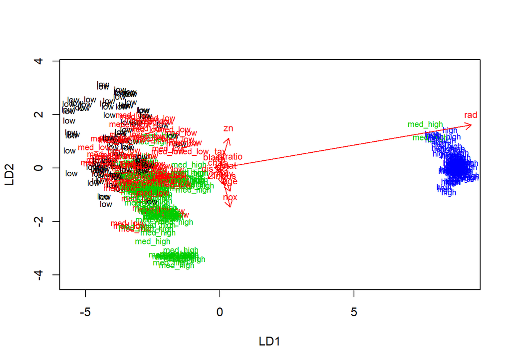

From the size of the arrows, we understand that ‘rad’, ‘nox’ (nitrogen oxides concentration, parts per 10 million) and ‘zn’ (proportion of residential land zoned for lots over 25,000 sq.ft) have the highest correlation on ‘crime’.

## Prediction on the test subset

Save the crime categories from the test set and then remove the categorical crime variable from the test dataset. Then predict the classes with the LDA model on the test data. Cross tabulate the results with the crime categories from the test set.

```
##           predicted
## correct    low med_low med_high high
##   low       18      10        2    0
##   med_low    6      15        6    0
##   med_high   1       5        9    4
##   high       0       0        1   25
```

From the cross table, we observe that about 65-70% of the predictions are correct. The remaining 30-35% have been uncorrectly classified. (The percentage varies alightly according to how the subsets train and test are randomly selected)